# Week 7 - Data Dive - Hypothesis Testing

## Fisher’s Significance Testing

## Hypothesis 2: Is there a difference in overall ratings between players from different nationalities?

*Null Hypothesis:* There is no association between a player’s nationality and their overall rating category (high vs low). *Alternative Hypothesis:* There is an association between a player’s nationality and their overall rating category (high vs low).

For this hypothesis, we will perform Fisher’s exact test to evaluate the relationship between nationality and overall rating.

## Fishers’s exact test

```r
# List of main football countries
main_countries <- c("Brazil", "Argentina", "Germany")

# Filter the dataset for main football countries
main_football_data <- data |>
  filter(nationality %in% main_countries)


# Categorize overall ratings into 'High' (>=70) and 'Low' (<70)
main_football_data$rating_category <- ifelse(main_football_data$overall_rating >= 70, "High", "Low")

# Create a contingency table between nationality and rating category
contingency_table <- table(main_football_data$nationality, main_football_data$rating_category)

# View the table to see the data distribution
print(head(contingency_table))
```

```
##
##             High Low
##   Argentina  434 470
##   Brazil     511 321
##   Germany    310 889
```

## Perform Fisher’s Exact Test

```r
# Increase the workspace and rerun Fisher's Exact Test
fisher_test_result <- fisher.test(contingency_table, workspace = 2e8)  # Increase workspace size

# View the result
fisher_test_result
```

```
##
##  Fisher's Exact Test for Count Data
##
## data:  contingency_table
## p-value < 2.2e-16
## alternative hypothesis: two.sided
```

### Results

P-Value: The p-value of 2.2e-16 is extremely small, indicating a very strong statistical significance.

Because p-value is so small, you reject the null hypothesis. This means there is strong evidence to suggest that there are significant differences in overall ratings among players from different nationalities.

### Visualisation

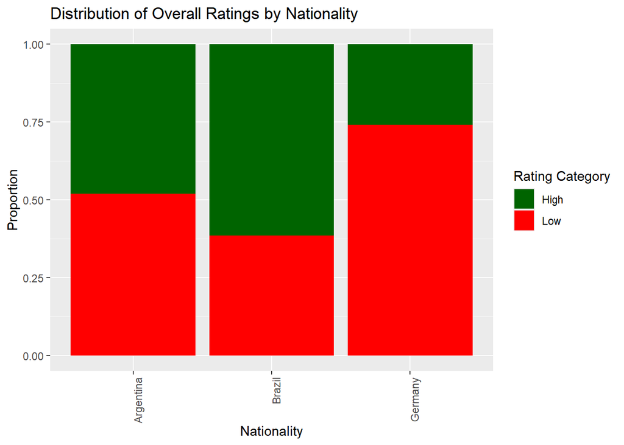

```r
# Create a bar plot showing the distribution of rating categories by nationality
ggplot(main_football_data, aes(x = nationality, fill = rating_category)) +
  geom_bar(position = "fill") +
  labs(title = "Distribution of Overall Ratings by Nationality",
       x = "Nationality", y = "Proportion",
       fill = "Rating Category") +
  theme(axis.text.x = element_text(angle = 90, hjust = 1)) +
  scale_fill_manual(values = c("High" = "darkgreen", "Low" = "red"))
```

## Further questions

1. Which specific nationalities show the most significant differences in overall ratings? Are there patterns in performance based on geography or cultural factors?
2. Are there other player attributes (like age, height, or position) that correlate with overall ratings? How do these factors interact with nationality in influencing player performance?